# week1.hw.md.11.2.26

## 2e: 5 genes with the highest average expression and the 5 with the lowest average expression

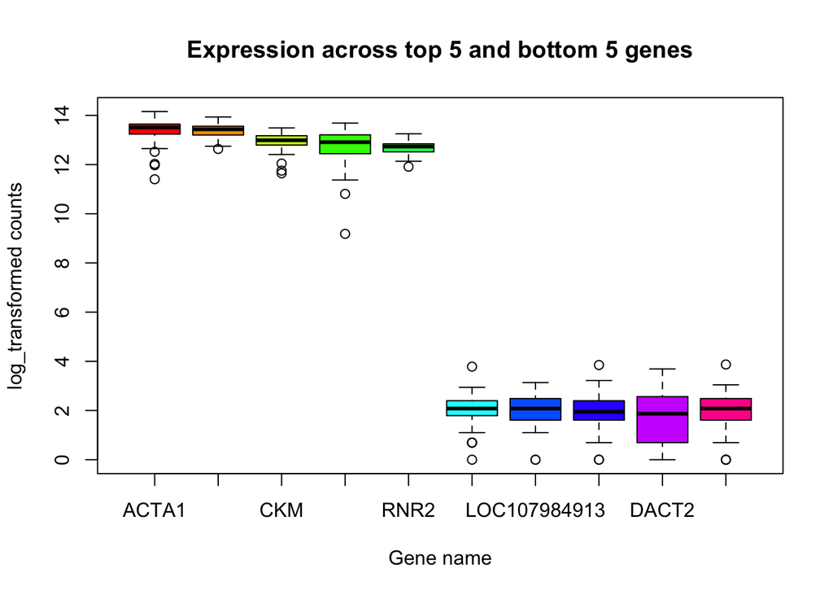

```r
names(row_avg_perGene) <- gse226151_data$SYMBOL
sorted_gene_means <- sort( row_avg_perGene)
bot_5_genes<- sort( row_avg_perGene)[1:5]
top_5_genes<-sort(row_avg_perGene , decreasing = T)[1:5]

comb <- c(names(top_5_genes), names(bot_5_genes))
df_top_bot <- data.table(Gene = rep(comb, each = ncol(dfr_raw)),
                   Count = as.vector(t(dfr_raw[match(comb, rownames(dfr_raw)), ])))

df_top_bot$Gene <- factor(df_top_bot$Gene, levels = comb)

boxplot( log ( df_top_bot$Count) ~df_top_bot$Gene , col = rainbow(10) ,
         main = "Expression across top 5 and bottom 5 genes",
         ylab = "log_transformed counts",
         xlab = "Gene name"
         )
```

## 2f: volcano plot of the differential expression results (log2 fold change on the x-axis, −log10

adjusted p-value on the y-axis) in ggplot2

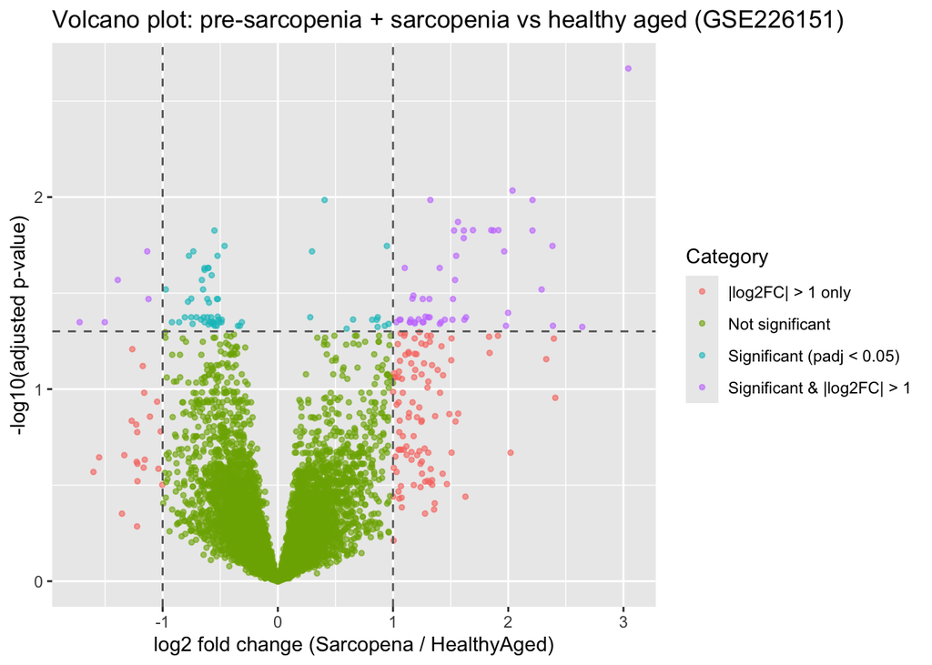

```r
volc_df<- gse226151_data[!is.na(gse226151_data$padj) & !is.na(gse226151_data$log2FoldChange), ]

volc_df$negLogPadj <- -log10(volc_df$padj)


fin <- max(volc_df$negLogPadj[is.finite(volc_df$negLogPadj)])

volc_df$negLogPadj[is.infinite(volc_df$negLogPadj)] <- fin * 1.05

volc_df$Category <- ifelse(volc_df$padj < 0.05 & abs(volc_df$log2FoldChange) > 1,
                        "Significant & |log2FC| > 1",
                 ifelse(volc_df$padj < 0.05, "Significant (padj < 0.05)",
                 ifelse(abs(volc_df$log2FoldChange) > 1, "|log2FC| > 1 only",
                        "Not significant")))

ggplot(
  volc_df,  aes( log2FoldChange , negLogPadj , color = Category) )+
  geom_point(alpha = 0.6, size = 1) +
  geom_vline(xintercept = c(-1, 1), linetype = "dashed", color = "grey40")+
  geom_hline(yintercept = -log10(0.05), linetype = "dashed", color = "grey40")+
    labs(title = "Volcano plot: pre-sarcopenia + sarcopenia vs healthy aged (GSE226151)",
       x = "log2 fold change (Sarcopena / HealthyAged)",
       y = "-log10(adjusted p-value)")
```

Interpretation: The various points make up all the genes present. the 2 comparison groups, sarcopena and healthyAged are separated at the origin; right and left respectively. the y-axis represents statistical confidence and genes above the the horizontal line are more significant with p<0.05. Biologically, the colored corner points are the genes whose expression in skeletal muscle differs between the sarcopenia and healthy aging strongly enough to influence or induce carcopenic muscles, but this does not conclude that all points indicating folding or significance are biologically reliable.

## 2g: MA plot (average expression on the x-axis, log2 fold change on the y-axis) via ggplot2

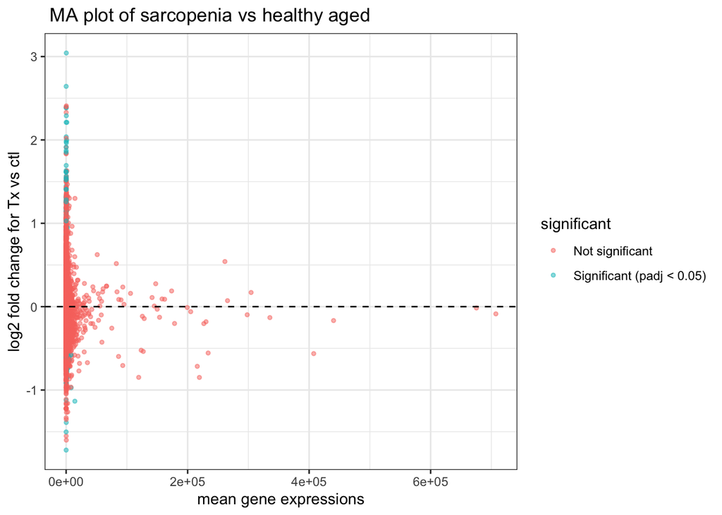

```r
ma_df <- data.frame(
  mean_expression = row_avg_perGene,
  log2FoldChange =  gse226151_data$log2FoldChange,
   padj = gse226151_data$padj
)

ma_df$significant <- ifelse(ma_df$padj < 0.05,
                            "Significant (padj < 0.05)", "Not significant")

ggplot( ma_df ,
        aes( x = mean_expression , y = log2FoldChange , colour = significant ))+
  geom_point( size = 1, alpha = 0.5)+
  geom_hline( yintercept = 0, linetype = "dashed")+
  labs(
    title =" MA plot of sarcopenia vs healthy aged",
    x = "mean gene expressions",
    y = "log2 fold change for Tx vs ctl"
  )+ theme_bw()
```

The above MA plot demonstrates how much each gene is expressed on average along the x-axis Vs how much much it regulation influence on treatment it has. genes above the origin (0) are up-regulated while those below are down-regulated in treatment. While MA plot check for whether fold changes are consistent expression levels, Volcana plot put the significance on the y-axis to show which genes in particular are confidently changed.

## 3a. SummarizedExperiment with at minimum two assay matrices in gse226151_data

```r
library(SummarizedExperiment)

sampleCols <- grep("^GSM", colnames(gse226151_data), value = TRUE)

groups <- rep(c("0", "X", "1"), c(20, 19, 19))

names(groups) <- sampleCols
subb <- names(groups)[groups != "X"]


RowNames <- as.character(gse226151_data$ENTREZID)
countMat <- as.matrix(gse226151_data[ , ..subb])

dimnames(countMat) <- list(RowNames, subb)
logCPMMat <- log2(t(t(countMat) / colSums(countMat)) * 1e6 + 1)
dimnames(logCPMMat) <- dimnames(countMat)


RowData <- data.frame(SYMBOL = gse226151_data$SYMBOL,
                      log2FoldChange = gse226151_data$log2FoldChange,
                      padj = gse226151_data$padj,
                      row.names = RowNames)

ColData <- data.frame(Treatment = ifelse(groups[subb] == "1", "Tx", "Ctrl"),
                      row.names = subb)

SE <- SummarizedExperiment(assays = list(counts = countMat, logCPM = logCPMMat),
                           rowData = RowData, colData = ColData)
SE
```

```
## class: SummarizedExperiment
## dim: 15945 39
## metadata(0):
## assays(2): counts logCPM
## rownames(15945): 1 2 ... 114841035 115253422
## rowData names(3): SYMBOL log2FoldChange padj
## colnames(39): GSM7065818 GSM7065819 ... GSM7065876 GSM7065877
## colData names(1): Treatment
```

## 3b: row and column names verification

```r
identical(rownames(ColData), colnames(countMat))
```

```
## [1] TRUE
```

```r
identical(rownames(ColData), colnames(logCPMMat))
```

```
## [1] TRUE
```

```r
identical(rownames(RowData), rownames(countMat))
```

```
## [1] TRUE
```

```r
(SE <- SummarizedExperiment(assays = list(counts = countMat, logCPM = logCPMMat),
                            rowData = RowData, colData = ColData))
```

```
## class: SummarizedExperiment
## dim: 15945 39
## metadata(0):
## assays(2): counts logCPM
## rownames(15945): 1 2 ... 114841035 115253422
## rowData names(3): SYMBOL log2FoldChange padj
## colnames(39): GSM7065818 GSM7065819 ... GSM7065876 GSM7065877
## colData names(1): Treatment
```

## 3c: subsetting the SummarizedExperiment

```r
#i : treatment samples using the column metadata

SE_treatment <- SE[, colData(SE)$Treatment == "Tx"]
dim(SE_treatment)
```

```
## [1] 15945    19
```

```r
#ii: Selecting only significantly differentially expressed genes (adjusted p-value < 0.05) using the row metadata.

sig_expressed_genes <- SE[ !is.na (rowData(SE)$padj) & rowData(SE)$padj < 0.05, ]

# iii: Combining both filters simultaneously.

SE_Tx_Sig <- SE[!is.na(rowData(SE)$padj) & rowData(SE)$padj < 0.05, colData(SE)$Treatment == "Tx"]
```

## 3d: Access the raw expression values for the top 5 differentially expressed genes

```r
top5_by_p.value <- rownames(SE)[order(rowData(SE)$padj)][1:5]
top5Counts <- assays(SE)[["counts"]][top5_by_p.value, ]
rownames(top5Counts) <- paste0(rowData(SE)[top5_by_p.value, "SYMBOL"], " (", top5_by_p.value, ")")

tbl <- data.frame( top5Counts)
```

## 3e:

SummarizedExperiment holds the expression matrices, the gene annotations and the sample annotations in one object, and it keeps them aligned by name. Rows always matching gens and coulumns matching samples keeps the data in sync and ensure ease access. rows always match genes, columns always match samples. SE would be preferred over dataframe when dealing with genomic data with many samples per gene with additional metadata.Also, with dealing with data that has 2 axes, SE will be better than dataframe.

## 4.

Bioconductor objects orient data with genes as rows and samples as columns because genomic data metadata such as gene IDs, symbols, coordinates, DE statistics compared to the columns which often carry gene names. analyses can also be applied to rows more broadly. But stats tools like lm() expect the opposite thus one sample per row transposing.

#—— github link: https://github.com/m45st/RBIF111-Bioinformatics/blob/main/Week%201%20Intro%20to%20fundamentals%20of%20R%2C%20obtaining%20open%20source%20data%2C%20and%20data%20management%20containers/11.2.26.week1.hw.md.Rmd #——-